# Comparing geotagged tweet volumes available with the Twitter Premium Search API, the Twitter Search API, and TWINT

## Setup and search for tweets using the Twitter Premium Search API (counts endpoint)

```python
# I used the TwitterAPI Python package as a convenient wrapper for the API requests
from TwitterAPI import TwitterAPI
import pandas as pd
pd.set_option('max_columns', None)
import time
import json
import matplotlib.pyplot as plt
import numpy as np
import dateutil
import datetime
import matplotlib.dates as mdates

import seaborn as sns

# set up twitter API with Oauth keys. These should be set elsewhere and kept secret!
api = TwitterAPI(consumer_key, consumer_secret, access_token_key, access_token_secret)
```

```python
resp_hourly = api.request("tweets/search/30day/:dev/counts", {"query": "(urgent OR help) point_radius:[77.232410 28.637459 40km]"})
```

```python
dfa = pd.DataFrame(resp_hourly.json()['results'])
dfa['timePeriod'] = dfa['timePeriod'].apply(lambda v: pd.to_datetime(v))
```

```python
resp_daily = api.request("tweets/search/30day/:dev/counts", {"query": "(urgent OR help) point_radius:[77.232410 28.637459 40km]", "bucket": "day"})
```

```python
dfa2 = pd.DataFrame(resp_daily.json()['results'])
dfa2['timePeriod'] = dfa2['timePeriod'].apply(lambda v: pd.to_datetime(v))
```

### How do the hourly and daily endpoints compare?

When grouped by day, the hourly data is a close match to the daily data. However, especially for days with low tweet volume, the aggregated hourly data appears to be a slight over-estimate. This is explained by the quantization of low value aggregate data, seen below.

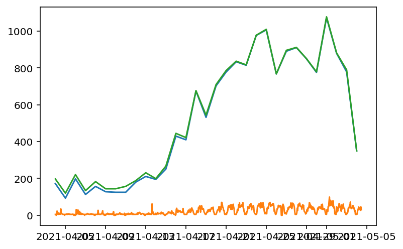

```python
plt.plot(dfa2['timePeriod'], dfa2['count'])
plt.plot(dfa['timePeriod'], dfa['count'])
plt.plot(dfa.groupby(pd.Grouper(freq='1D', key='timePeriod')).sum()['count'])
```

### Quantization of data

The counts endpoint appears to quantize/obfuscate any counts between 1 and 5 to a value of 5. Interestingly, this only appears to be the case for georeferenced queries. (Shown further below in this notebook.)

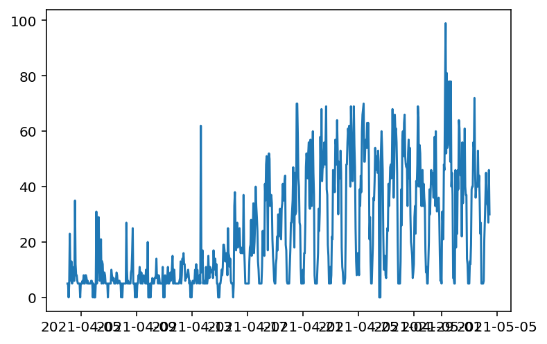

```python
plt.plot(dfa['timePeriod'], dfa['count'])
```

## Setup and search for tweets using TWINT

```python
import asyncio
import aiohttp
import nest_asyncio
nest_asyncio.apply()
import twint
```

```python
# search query with geocode. This is the same as the query used to test the Premium Search API above, but with slightly different syntax
twintq = '(urgent OR help) AND geocode:28.637459,77.232410,40km'

c = twint.Config()

c.Search = twintq
c.Store_csv = True
c.Output = "/Users/loganw/test.csv"
c.Hide_output = True
c.Since = "2021-04-04"

twint.run.Search(c)
```

```
[!] No more data! Scraping will stop now.
found 0 deleted tweets in this search.
```

```python
# read TWINT CSV as a Pandas DataFrame
dft = pd.read_csv('/Users/loganw/test.csv', parse_dates=['created_at'])
```

```python
# group the TWINT tweets by hour
grp = dft.groupby(pd.Grouper(freq='1H', key='created_at'))
```

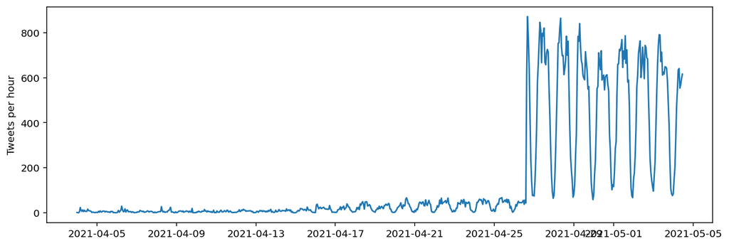

```python
plt.figure(figsize=(12,4))
plt.plot(grp.count()['id'])
plt.ylabel('Tweets per hour')
```

### How does this compare to the Premium Search API counts?

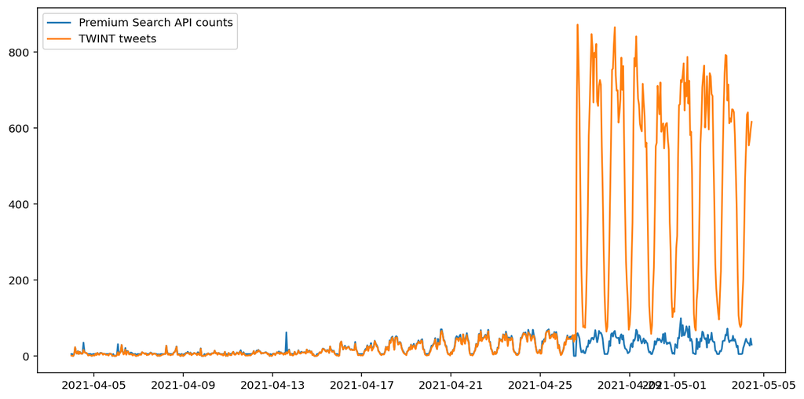

```python
plt.figure(figsize=(12,6))
plt.plot(dfa['timePeriod'], dfa['count'])
plt.plot(grp.count()['id'])
plt.legend(['Premium Search API counts', 'TWINT tweets'])
```

It appears that there are many more tweets returned by TWINT in the previous 7 days than are counted by the Premium Search API. However, beyond this period, they are very similar. (Except for a few cases of *more* tweets returned by the Premium Search API counts endpoint, which could be a consequence of deleted tweets.)

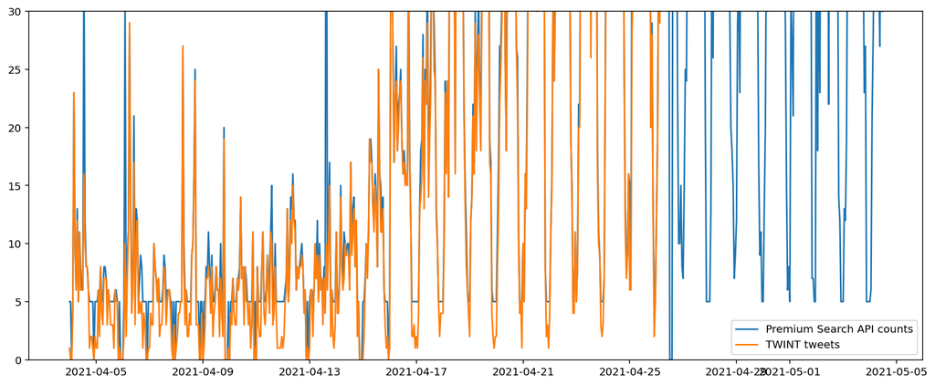

```python
plt.figure(figsize=(15,6))
plt.plot(dfa['timePeriod'], dfa['count'])

plt.plot(grp.count()['id'])
plt.ylim([0,30])
plt.legend(['Premium Search API counts', 'TWINT tweets'])
```

On the lower left of the graph, the quantization of low value counts is very visible.

## What is different about the tweets that explains this volume discrepancy?

### Get tweets using the Premium Search API

Use the search endpoint instead of the counts endpoint to get actual tweets.

```python
resp_tweets = api.request("tweets/search/30day/:dev", {"query": "(urgent OR help) point_radius:[77.232410 28.637459 40km]", "maxResults": 500})
api_tweets = pd.DataFrame(resp_tweets.json()['results'])
api_tweets['created_at'] = api_tweets['created_at'].apply(lambda v: pd.to_datetime(v))
```

```python
c = twint.Config()

c.Search = twintq
c.Store_csv = True
c.Output = "/Users/loganw/twint_tweets_loc.csv"
c.Hide_output = True
c.Since = "2021-05-03"

twint.run.Search(c)
```

```
[!] No more data! Scraping will stop now.
found 0 deleted tweets in this search.
```

```python
twint_tweets = pd.read_csv('/Users/loganw/twint_tweets.csv', parse_dates=['created_at'])
```

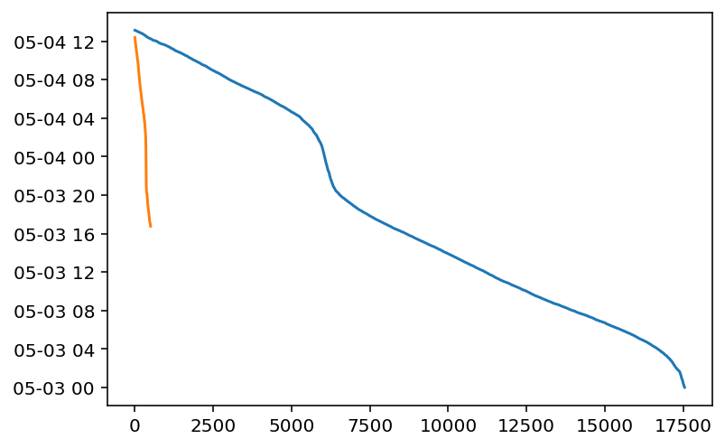

```python
# a quick check that the tweet datasets contain overlapping time information.
plt.plot(twint_tweets['created_at'])
plt.plot(api_tweets['created_at'])
```

Most tweets do not have explicit geo information.

```python
api_tweets[api_tweets['geo'].apply(lambda v: v is not None)]
```

|  | created_at | id | id_str | text | display_text_range | source | truncated | in_reply_to_status_id | in_reply_to_status_id_str | in_reply_to_user_id | in_reply_to_user_id_str | in_reply_to_screen_name | user | geo | coordinates | place | contributors | quoted_status_id | quoted_status_id_str | quoted_status | quoted_status_permalink | is_quote_status | extended_tweet | quote_count | reply_count | retweet_count | favorite_count | entities | favorited | … |
| --- | --- | --- | --- | --- | --- | --- | --- | --- | --- | --- | --- | --- | --- | --- | --- | --- | --- | --- | --- | --- | --- | --- | --- | --- | --- | --- | --- | --- | --- | --- |
| 129 | 2021-05-04 08:34:58+00:00 | 1389498775664791554 | 1389498775664791554 | #help #getvaccienated #registration #staysafe ... | NaN | <a href="http://instagram.com" rel="nofollow">... | True | NaN | None | NaN | None | None | {'id': 1085520064017772545, 'id_str': '1085520... | {'type': 'Point', 'coordinates': [28.6410658, ... | {'type': 'Point', 'coordinates': [77.08275231,... | {'id': '317fcc4b21a604d5', 'url': 'https://api... | None | NaN | NaN | NaN | NaN | False | {'full_text': '#help #getvaccienated #registra... | 0 | 0 | 0 | 0 | {'hashtags': [{'text': 'help', 'indices': [0, ... | False | … |
| 423 | 2021-05-03 18:37:15+00:00 | 1389287959271198729 | 1389287959271198729 | Need urgent assistance @ Delhi, India https://... | NaN | <a href="http://instagram.com" rel="nofollow">... | False | NaN | None | NaN | None | None | {'id': 936113527, 'id_str': '936113527', 'name... | {'type': 'Point', 'coordinates': [28.631747, 7... | {'type': 'Point', 'coordinates': [77.219672, 2... | {'id': '317fcc4b21a604d5', 'url': 'https://api... | None | NaN | NaN | NaN | NaN | False | NaN | 0 | 0 | 0 | 0 | {'hashtags': [], 'urls': [{'url': 'https://t.c... | False | … |

However, all seem to contain "place" information.

```python
api_tweets[api_tweets['place'].apply(lambda v: v is not None)]
```

|  | created_at | id | id_str | text | display_text_range | source | truncated | in_reply_to_status_id | in_reply_to_status_id_str | in_reply_to_user_id | in_reply_to_user_id_str | in_reply_to_screen_name | user | geo | coordinates | place | contributors | quoted_status_id | quoted_status_id_str | quoted_status | quoted_status_permalink | is_quote_status | extended_tweet | quote_count | reply_count | retweet_count | favorite_count | entities | favorited | … |
| --- | --- | --- | --- | --- | --- | --- | --- | --- | --- | --- | --- | --- | --- | --- | --- | --- | --- | --- | --- | --- | --- | --- | --- | --- | --- | --- | --- | --- | --- | --- |
| 0 | 2021-05-04 12:23:18+00:00 | 1389556236232761345 | 1389556236232761345 | Not required any help at WB they all are crim... | [0, 140] | <a href="http://twitter.com/download/android" ... | True | NaN | None | NaN | None | None | {'id': 1251881467505856517, 'id_str': '1251881... | None | None | {'id': '4d51b7ea67b6f64b', 'url': 'https://api... | None | 1.388856e+18 | 1388855746448695299 | {'created_at': 'Sun May 02 13:59:48 +0000 2021... | {'url': 'https://t.co/ZQMyhFkrz0', 'expanded':... | True | {'full_text': 'Not required any help at WB th... | 0 | 0 | 0 | 0 | {'hashtags': [], 'urls': [{'url': 'https://t.c... | False | … |
| 1 | 2021-05-04 12:22:49+00:00 | 1389556116862816261 | 1389556116862816261 | Who ever can please help!!!\n\n#covid #COVIDEm... | NaN | <a href="http://twitter.com/download/iphone" r... | False | 1.389555e+18 | 1389555145772462080 | 113897359.0 | 113897359 | the__himanish | {'id': 113897359, 'id_str': '113897359', 'name... | None | None | {'id': '317fcc4b21a604d5', 'url': 'https://api... | None | NaN | NaN | NaN | NaN | False | NaN | 0 | 0 | 0 | 0 | {'hashtags': [{'text': 'covid', 'indices': [29... | False | … |
| 2 | 2021-05-04 12:18:58+00:00 | 1389555145772462080 | 1389555145772462080 | Trying to help in any way I can.\n\n#covid #CO... | [0, 73] | <a href="http://twitter.com/download/iphone" r... | False | NaN | None | NaN | None | None | {'id': 113897359, 'id_str': '113897359', 'name... | None | None | {'id': '317fcc4b21a604d5', 'url': 'https://api... | None | NaN | NaN | NaN | NaN | False | NaN | 0 | 1 | 0 | 0 | {'hashtags': [{'text': 'covid', 'indices': [34... | False | … |
| 3 | 2021-05-04 12:17:45+00:00 | 1389554839936397313 | 1389554839936397313 | @sambhavnaseth @Priyajayant1 Hi sambhavana , n... | [29, 120] | <a href="http://twitter.com/download/android" ... | False | 1.389174e+18 | 1389174303833223172 | 170977970.0 | 170977970 | sambhavnaseth | {'id': 748314314499624960, 'id_str': '74831431... | None | None | {'id': '64231a922dea526e', 'url': 'https://api... | None | NaN | NaN | NaN | NaN | False | NaN | 0 | 0 | 0 | 0 | {'hashtags': [], 'urls': [], 'user_mentions': ... | False | … |
| 4 | 2021-05-04 12:16:08+00:00 | 1389554432463937539 | 1389554432463937539 | @narendramodi Sir please help no icu beds avai... | [14, 138] | <a href="http://twitter.com/download/android" ... | False | 1.389240e+18 | 1389239538313089024 | 18839785.0 | 18839785 | narendramodi | {'id': 748314314499624960, 'id_str': '74831431... | None | None | {'id': '64231a922dea526e', 'url': 'https://api... | None | NaN | NaN | NaN | NaN | False | NaN | 0 | 1 | 0 | 0 | {'hashtags': [], 'urls': [], 'user_mentions': ... | False | … |
| ... | ... | ... | ... | ... | ... | ... | ... | ... | ... | ... | ... | ... | ... | ... | ... | ... | ... | ... | ... | ... | ... | ... | ... | ... | ... | ... | ... | ... | ... | … |
| 495 | 2021-05-03 16:52:22+00:00 | 1389261563773739021 | 1389261563773739021 | India need #OxygenEmergency \nअभी हम सबको एक द... | NaN | <a href="http://twitter.com/download/android" ... | True | NaN | None | NaN | None | None | {'id': 1389234457207615498, 'id_str': '1389234... | None | None | {'id': '317fcc4b21a604d5', 'url': 'https://api... | None | NaN | NaN | NaN | NaN | False | {'full_text': 'India need #OxygenEmergency अभ... | 0 | 1 | 1 | 1 | {'hashtags': [{'text': 'OxygenEmergency', 'ind... | False | … |
| 496 | 2021-05-03 16:51:18+00:00 | 1389261293979258881 | 1389261293979258881 | Thanks for your support 🙏 AMEZ works by Gugugr... | [0, 140] | <a href="http://twitter.com/download/android" ... | True | NaN | None | NaN | None | None | {'id': 143736875, 'id_str': '143736875', 'name... | None | None | {'id': '317fcc4b21a604d5', 'url': 'https://api... | None | 1.389124e+18 | 1389124358182903809 | {'created_at': 'Mon May 03 07:47:10 +0000 2021... | {'url': 'https://t.co/FWv3Rue9yD', 'expanded':... | True | {'full_text': 'Thanks for your support 🙏 AMEZ ... | 0 | 0 | 0 | 0 | {'hashtags': [], 'urls': [{'url': 'https://t.c... | False | … |
| 497 | 2021-05-03 16:49:08+00:00 | 1389260748539400193 | 1389260748539400193 | Delhi CM Shri Kejriwal Ji should immediately g... | [0, 140] | <a href="http://twitter.com/download/android" ... | True | NaN | None | NaN | None | None | {'id': 944587346732752896, 'id_str': '94458734... | None | None | {'id': '317fcc4b21a604d5', 'url': 'https://api... | None | 1.389212e+18 | 1389212209436188673 | {'created_at': 'Mon May 03 13:36:15 +0000 2021... | {'url': 'https://t.co/Aa8Y0k4lRN', 'expanded':... | True | {'full_text': 'Delhi CM Shri Kejriwal Ji shoul... | 0 | 0 | 0 | 0 | {'hashtags': [], 'urls': [{'url': 'https://t.c... | False | … |
| 498 | 2021-05-03 16:47:22+00:00 | 1389260304689729542 | 1389260304689729542 | @rupashreenanda @SanjayAzadSln @AnitaSingh_ @_... | [56, 140] | <a href="http://twitter.com/download/android" ... | True | 1.388905e+18 | 1388905199830396932 | 146751977.0 | 146751977 | rupashreenanda | {'id': 72006548, 'id_str': '72006548', 'name':... | None | None | {'id': '317fcc4b21a604d5', 'url': 'https://api... | None | NaN | NaN | NaN | NaN | False | {'full_text': '@rupashreenanda @SanjayAzadSln ... | 0 | 0 | 0 | 1 | {'hashtags': [], 'urls': [{'url': 'https://t.c... | False | … |
| 499 | 2021-05-03 16:45:55+00:00 | 1389259939168743428 | 1389259939168743428 | @Voracious_af Hi brother, u help me alot. Than... | NaN | <a href="http://twitter.com/download/android" ... | False | NaN | None | 117085327.0 | 117085327 | Voracious_af | {'id': 1034416281259335685, 'id_str': '1034416... | None | None | {'id': '317fcc4b21a604d5', 'url': 'https://api... | None | NaN | NaN | NaN | NaN | False | NaN | 0 | 1 | 0 | 2 | {'hashtags': [], 'urls': [], 'user_mentions': ... | False | … |

500 rows × 35 columns

```python
twint_tweets['included'] = twint_tweets['id'].apply(lambda v: v in list(api_tweets['id']))
```

```python
twint_tweets[np.logical_not(twint_tweets['included'])]
```

|  | id | conversation_id | created_at | date | time | timezone | user_id | username | name | place | tweet | language | mentions | urls | photos | replies_count | retweets_count | likes_count | hashtags | cashtags | link | retweet | quote_url | video | thumbnail | near | geo | source | user_rt_id | … |
| --- | --- | --- | --- | --- | --- | --- | --- | --- | --- | --- | --- | --- | --- | --- | --- | --- | --- | --- | --- | --- | --- | --- | --- | --- | --- | --- | --- | --- | --- | --- |
| 0 | 1389567616314855424 | 1389567616314855424 | 2021-05-04 15:08:31+02:00 | 2021-05-04 | 15:08:31 | 200 | 741987952738377728 | anshmishra94 | ANSH MISHRA | NaN | Dear Sir, Kindly help us in this pandemic days... | en | [{'screen_name': 'dmsouthwest1', 'name': 'dm/d... | [] | ['https://pbs.twimg.com/media/E0i8YcjUcAQQVCW.... | 0 | 0 | 0 | [] | [] | https://twitter.com/anshmishra94/status/138956... | False | NaN | 1 | https://pbs.twimg.com/media/E0i8YcjUcAQQVCW.jpg | NaN | NaN | NaN | NaN | … |
| 1 | 1389567586208075788 | 1389566912200253441 | 2021-05-04 15:08:24+02:00 | 2021-05-04 | 15:08:24 | 200 | 2302564298 | jeetuoutlook | Jeetu Sharma | NaN | @RubikaLiyaquat 🆘 urgent Require Plasma Bloo... | en | [] | [] | [] | 0 | 0 | 1 | [] | [] | https://twitter.com/JeetuOutlook/status/138956... | False | NaN | 0 | NaN | NaN | NaN | NaN | NaN | … |
| 2 | 1389567573637795846 | 1385321514279477249 | 2021-05-04 15:08:21+02:00 | 2021-05-04 | 15:08:21 | 200 | 1389541510165635072 | sharmaricha26 | Richa Sharma | NaN | @hiteshsharma_7 Hi I need urgently ventilator ... | en | [] | [] | [] | 0 | 0 | 0 | [] | [] | https://twitter.com/sharmaRicha26/status/13895... | False | NaN | 0 | NaN | NaN | NaN | NaN | NaN | … |
| 3 | 1389567556873166852 | 1389566997038436355 | 2021-05-04 15:08:17+02:00 | 2021-05-04 | 15:08:17 | 200 | 3193112497 | bsesdelhi | BSES Delhi | NaN | @Deen_Aligarian It would be great if you could... | en | [] | [] | [] | 0 | 0 | 0 | [] | [] | https://twitter.com/bsesdelhi/status/138956755... | False | NaN | 0 | NaN | NaN | NaN | NaN | NaN | … |
| 4 | 1389567527328509958 | 1389459917078106112 | 2021-05-04 15:08:10+02:00 | 2021-05-04 | 15:08:10 | 200 | 1667354024 | help_delhivery | helpdesk_delhivery | NaN | @Aarav63950265 Kindly allow us some time as th... | en | [] | [] | [] | 0 | 0 | 0 | [] | [] | https://twitter.com/help_delhivery/status/1389... | False | NaN | 0 | NaN | NaN | NaN | NaN | NaN | … |
| ... | ... | ... | ... | ... | ... | ... | ... | ... | ... | ... | ... | ... | ... | ... | ... | ... | ... | ... | ... | ... | ... | ... | ... | ... | ... | ... | ... | ... | ... | … |
| 17537 | 1389007185074548736 | 1388574853196705794 | 2021-05-03 02:01:34+02:00 | 2021-05-03 | 02:01:34 | 200 | 3959099054 | neerajdegreat | Neeraj Awasthi | NaN | @SonuSood @SoodFoundation Hi @SonuSood one of ... | en | [{'screen_name': 'sonusood', 'name': 'sonu soo... | [] | [] | 0 | 0 | 0 | [] | [] | https://twitter.com/neerajdegreat/status/13890... | False | NaN | 0 | NaN | NaN | NaN | NaN | NaN | … |
| 17538 | 1389007034570346500 | 1388911082903719938 | 2021-05-03 02:00:58+02:00 | 2021-05-03 | 02:00:58 | 200 | 89141954 | ricky_insomniac | Behosh Item | NaN | @RichardDawkins @RichardDawkins This is side e... | en | [] | [] | [] | 0 | 0 | 1 | [] | [] | https://twitter.com/ricky_insomniac/status/138... | False | NaN | 0 | NaN | NaN | NaN | NaN | NaN | … |
| 17539 | 1389007031567192065 | 1389007031567192065 | 2021-05-03 02:00:57+02:00 | 2021-05-03 | 02:00:57 | 200 | 96164693 | frolicky | KantSurya | NaN | #SahareKaHath #SOS #Plasma #PlasmaDonor #COVID... | und | [] | [] | [] | 0 | 0 | 0 | ['saharekahath', 'sos', 'plasma', 'plasmadonor... | [] | https://twitter.com/frolicky/status/1389007031... | False | https://twitter.com/TheOutspokenBoy/status/138... | 0 | NaN | NaN | NaN | NaN | NaN | … |
| 17540 | 1389006971794198529 | 1389006971794198529 | 2021-05-03 02:00:43+02:00 | 2021-05-03 | 02:00:43 | 200 | 837199895022956545 | prajapatiji011 | Kashmir Singh Prajapati | NaN | Even the embassies are seeking help from the O... | en | [] | [] | ['https://pbs.twimg.com/media/E0a-dygVkAIW9g1.... | 0 | 0 | 0 | [] | [] | https://twitter.com/Prajapatiji011/status/1389... | False | NaN | 1 | https://pbs.twimg.com/media/E0a-dygVkAIW9g1.jpg | NaN | NaN | NaN | NaN | … |
| 17541 | 1389006918572597252 | 1389006918572597252 | 2021-05-03 02:00:30+02:00 | 2021-05-03 | 02:00:30 | 200 | 96164693 | frolicky | KantSurya | NaN | #SahareKaHath #SOS #Plasma #PlasmaDonor #COVID... | und | [] | [] | [] | 0 | 0 | 0 | ['saharekahath', 'sos', 'plasma', 'plasmadonor... | [] | https://twitter.com/frolicky/status/1389006918... | False | https://twitter.com/honeysinghfb/status/138808... | 0 | NaN | NaN | NaN | NaN | NaN | … |

17050 rows × 37 columns

Tweets that were found by TWINT and by the Premium Search include a Twitter "place," as in this example: https://twitter.com/SumatiThusoo/status/1389522172671037442

Tweets that were found by TWINT but not by the Premium Search API do not. It appears that information on location is being sourced from the user's profile location in this case.

Unfortunately, very few TWINT tweets contain populated "place" information, even tweets which include a place in the Twitter web interface. It is unknown why this is the case.

```python
twint_tweets[twint_tweets['place'].apply(lambda v: type(v) != float)]
```

|  | id | conversation_id | created_at | date | time | timezone | user_id | username | name | place | tweet | language | mentions | urls | photos | replies_count | retweets_count | likes_count | hashtags | cashtags | link | retweet | quote_url | video | thumbnail | near | geo | source | user_rt_id | … |
| --- | --- | --- | --- | --- | --- | --- | --- | --- | --- | --- | --- | --- | --- | --- | --- | --- | --- | --- | --- | --- | --- | --- | --- | --- | --- | --- | --- | --- | --- | --- |
| 36 | 1389566757132595204 | 1389566757132595204 | 2021-05-04 15:05:06+02:00 | 2021-05-04 | 15:05:06 | 200 | 149585330 | pairsonnalitesa | Stigmabase \| AS | {'type': 'Point', 'coordinates': [28.5974128, ... | INNR — My parents do not know where Harvard is... | en | [] | ['http://dlvr.it/Rz1np3'] | [] | 0 | 0 | 0 | [] | [] | https://twitter.com/PairsonnalitesA/status/138... | False | NaN | 0 | NaN | NaN | NaN | NaN | NaN | … |
| 2725 | 1389498775664791554 | 1389498775664791554 | 2021-05-04 10:34:58+02:00 | 2021-05-04 | 10:34:58 | 200 | 1085520064017772545 | sagarmotors | Sagar Motors | {'type': 'Point', 'coordinates': [28.6410658, ... | #help #getvaccienated #registration #staysafe ... | no | [{'screen_name': 'surajkalra', 'name': 'suraj ... | ['https://www.instagram.com/p/COccvurAt97/?igs... | [] | 0 | 0 | 0 | ['help', 'getvaccienated', 'registration', 'st... | [] | https://twitter.com/SagarMotors/status/1389498... | False | NaN | 0 | NaN | NaN | NaN | NaN | NaN | … |
| 7093 | 1389287959271198729 | 1389287959271198729 | 2021-05-03 20:37:15+02:00 | 2021-05-03 | 20:37:15 | 200 | 936113527 | j69293418 | Brown boy | {'type': 'Point', 'coordinates': [28.631747, 7... | Need urgent assistance @ Delhi, India https:/... | en | [] | ['https://www.instagram.com/p/COa82wzFTHW6UqpI... | [] | 0 | 0 | 0 | [] | [] | https://twitter.com/j69293418/status/138928795... | False | NaN | 0 | NaN | NaN | NaN | NaN | NaN | … |

Unfortunately, the TWINT "Location" option is currently non-functional. This means that it is not possible to distinguish the tweets that only match based on the user's profile location.

```python
twint_tweets[twint_tweets['geo'].apply(lambda v: type(v) != float)]
```

|  | id | conversation_id | created_at | date | time | timezone | user_id | username | name | place | tweet | language | mentions | urls | photos | replies_count | retweets_count | likes_count | hashtags | cashtags | link | retweet | quote_url | video | thumbnail | near | geo | source | user_rt_id | … |
| --- | --- | --- | --- | --- | --- | --- | --- | --- | --- | --- | --- | --- | --- | --- | --- | --- | --- | --- | --- | --- | --- | --- | --- | --- | --- | --- | --- | --- | --- | --- |

**From these observations we can conclude that the difference in tweet volume is caused by the Twitter Advanced Search (and therefore TWINT as well) including tweets based on the user's profile location information, but only for the most recent seven days.** This means that tweet volume measured using TWINT from the most recent seven days cannot be compared with volume beyond that time range.

## Getting tweets with the normal Twitter Search API

```python
tweets = []

# the max_id parameter lets us request additional pages of tweets. We will start with
# this set to false to indicate that we are requesting the first page
maxid = False

# make up to 2000 requests
for i in range(2000):
    print(i)
    if maxid:
        resp = api.request("search/tweets", {"q": twintq, "result_type": "recent", "count": 100, "tweet_mode": "extended", "max_id": maxid})
    else:
        resp = api.request("search/tweets", {"q": twintq, "result_type": "recent", "count": 100, "tweet_mode": "extended"})

    response = resp.json()

    # we might get rate limited, which resets after 15 minutes
    if 'errors' in response and response['errors'][0]['code'] == 88:
        print("rate limit error, waiting 15 minutes")
        time.sleep(15*60)
    elif 'statuses' in response:
        statuses = response['statuses']

        # print the time of the last status in this set, for monitoring purposes
        print(statuses[-1]['created_at'])

        # add statuses to tweet list
        tweets += statuses

        if statuses[-1]['id'] == maxid:
            break
        maxid = statuses[-1]['id']
    else:
        print("other error")
        print(response)
        time.sleep(60)
```

```python
search_api_tweets = pd.DataFrame(tweets)
```

```python
# exclude retweets
search_api_norts = search_api_tweets[search_api_tweets['retweeted_status'].apply(lambda v: type(v) is float)]
```

```python
search_api_norts['created_at'] = search_api_norts['created_at'].apply(lambda v: pd.to_datetime(v))
```

```
(18750.0, 18751.5)
```

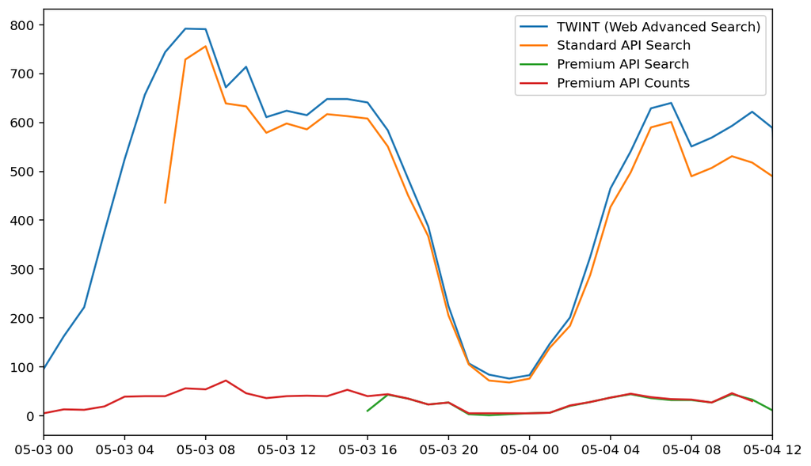

```python
plt.figure(figsize=(10,6))
plt.plot(twint_tweets.groupby(pd.Grouper(key='created_at', freq='1H')).count()['id'])
plt.plot(search_api_norts.groupby(pd.Grouper(key='created_at', freq='1H')).count()['id'])
plt.plot(api_tweets.groupby(pd.Grouper(key='created_at', freq='1H')).count()['id'])
plt.plot(dfa['timePeriod'], dfa['count'])

plt.legend(['TWINT (Web Advanced Search)', 'Standard API Search', 'Premium API Search', 'Premium API Counts'])
plt.xlim(twint_tweets.groupby(pd.Grouper(key='created_at', freq='1H')).count().index[0], twint_tweets.groupby(pd.Grouper(key='created_at', freq='1H')).count().index[-2])
```

The standard Twitter Search API appears to match the behavior of TWINT, however it returns slightly fewer tweets. It is not immediately clear why certain tweets are not included.

```python
twint_subset = twint_tweets[twint_tweets['created_at'].apply(lambda v: v > pd.to_datetime('2021-05-03 12:00:00Z') and v < pd.to_datetime('2021-05-03 20:00:00Z'))]
```

```python
twint_subset[twint_subset['id'].apply(lambda v: v not in list(search_api_norts['id']))]
```

|  | id | conversation_id | created_at | date | time | timezone | user_id | username | name | place | tweet | language | mentions | urls | photos | replies_count | retweets_count | likes_count | hashtags | cashtags | link | retweet | quote_url | video | thumbnail | near | geo | source | user_rt_id | … |
| --- | --- | --- | --- | --- | --- | --- | --- | --- | --- | --- | --- | --- | --- | --- | --- | --- | --- | --- | --- | --- | --- | --- | --- | --- | --- | --- | --- | --- | --- | --- |
| 6547 | 1389308659356737537 | 1389308659356737537 | 2021-05-03 21:59:31+02:00 | 2021-05-03 | 21:59:31 | 200 | 2433805362 | danceofminds | Sourav Mitra | NaN | #PSF 4may 1.23am 1. For not caring4elders &am... | en | [] | [] | [] | 0 | 0 | 0 | ['psf'] | [] | https://twitter.com/danceofminds/status/138930... | False | https://twitter.com/danceofminds/status/138930... | 0 | NaN | NaN | NaN | NaN | NaN | … |
| 6548 | 1389308642416107525 | 1389308642416107525 | 2021-05-03 21:59:27+02:00 | 2021-05-03 | 21:59:27 | 200 | 388956460 | sendmanishkumar | Manish kumar | NaN | Urgent need for 20 million vaccines to cover s... | en | [] | ['https://answersadda.com/pressing-want-for-20... | [] | 0 | 0 | 0 | [] | [] | https://twitter.com/sendmanishkumar/status/138... | False | NaN | 0 | NaN | NaN | NaN | NaN | NaN | … |
| 6559 | 1389308063375527942 | 1389308063375527942 | 2021-05-03 21:57:09+02:00 | 2021-05-03 | 21:57:09 | 200 | 889705398076186624 | devende17081984 | Devender Rawat | NaN | @fortis_hospital @PMOIndia @mlkhattar @MoHFW_I... | en | [{'screen_name': 'pmoindia', 'name': 'pmo indi... | [] | [] | 0 | 0 | 0 | [] | [] | https://twitter.com/Devende17081984/status/138... | False | https://twitter.com/Devende17081984/status/138... | 0 | NaN | NaN | NaN | NaN | NaN | … |
| 6567 | 1389307634151411712 | 1389307634151411712 | 2021-05-03 21:55:26+02:00 | 2021-05-03 | 21:55:26 | 200 | 4632724398 | puneet23011984 | Puneet Bhatia | NaN | @DC_Faridabad @yashpalmurar Dear Yashpal Ji, ... | en | [{'screen_name': 'yashpalmurar', 'name': 'yada... | [] | [] | 1 | 0 | 1 | [] | [] | https://twitter.com/Puneet23011984/status/1389... | False | https://twitter.com/enviara/status/13888206223... | 0 | NaN | NaN | NaN | NaN | NaN | … |
| 6580 | 1389307069866536960 | 1389307069866536960 | 2021-05-03 21:53:12+02:00 | 2021-05-03 | 21:53:12 | 200 | 122646612 | mslittlelawyer | Mansi Batra | NaN | Need non covid icu bed in Delhi URGENT @SonuSo... | en | [{'screen_name': 'sonusood', 'name': 'sonu soo... | [] | [] | 1 | 0 | 0 | [] | [] | https://twitter.com/MsLittleLawyer/status/1389... | False | NaN | 0 | NaN | NaN | NaN | NaN | NaN | … |
| ... | ... | ... | ... | ... | ... | ... | ... | ... | ... | ... | ... | ... | ... | ... | ... | ... | ... | ... | ... | ... | ... | ... | ... | ... | ... | ... | ... | ... | ... | … |
| 11102 | 1389190114471911431 | 1389190114471911431 | 2021-05-03 14:08:27+02:00 | 2021-05-03 | 14:08:27 | 200 | 1256587499956244480 | pramilak25 | Pramila | NaN | @RubikaLiyaquat everyone is talking for covid ... | en | [] | ['http://Education.Today'] | [] | 0 | 0 | 0 | [] | [] | https://twitter.com/pramilak25/status/13891901... | False | NaN | 0 | NaN | NaN | NaN | NaN | NaN | … |
| 11106 | 1389190033949839366 | 1389190033949839366 | 2021-05-03 14:08:08+02:00 | 2021-05-03 | 14:08:08 | 200 | 284859592 | 9050898887 | Amit joon | NaN | @anilvijminister sir namaskar!! I am from vpo ... | en | [] | [] | [] | 0 | 0 | 0 | [] | [] | https://twitter.com/9050898887/status/13891900... | False | NaN | 0 | NaN | NaN | NaN | NaN | NaN | … |
| 11122 | 1389189609892900865 | 1389189609892900865 | 2021-05-03 14:06:27+02:00 | 2021-05-03 | 14:06:27 | 200 | 368303392 | ravish2808 | Ravish Sinha | NaN | @taapsee @drharshvardhan @CovidIndiaSeva need... | en | [{'screen_name': 'drharshvardhan', 'name': 'dr... | [] | [] | 0 | 0 | 0 | [] | [] | https://twitter.com/Ravish2808/status/13891896... | False | https://twitter.com/Ravish2808/status/13891885... | 0 | NaN | NaN | NaN | NaN | NaN | … |
| 11138 | 1389189191691472897 | 1389189191691472897 | 2021-05-03 14:04:47+02:00 | 2021-05-03 | 14:04:47 | 200 | 135044487 | arundeepak1987 | Arun Kumar Sharma | NaN | @ArvindKejriwal @msisodia Sir I have tried fi... | en | [{'screen_name': 'msisodia', 'name': 'manish s... | [] | ['https://pbs.twimg.com/media/E0dkNCfVIAAnS9Q.... | 0 | 0 | 0 | [] | [] | https://twitter.com/arundeepak1987/status/1389... | False | NaN | 1 | https://pbs.twimg.com/media/E0dkNCfVIAAnS9Q.jpg | NaN | NaN | NaN | NaN | … |
| 11143 | 1389189001538506755 | 1389189001538506755 | 2021-05-03 14:04:02+02:00 | 2021-05-03 | 14:04:02 | 200 | 1379403403042807809 | amniraghav | Amrita Singh | NaN | @SonuSood sir plz help me for a bed with oxgen... | en | [{'screen_name': 'dmgbnagar', 'name': 'dm g.b.... | [] | [] | 0 | 0 | 0 | [] | [] | https://twitter.com/Amniraghav/status/13891890... | False | NaN | 0 | NaN | NaN | NaN | NaN | NaN | … |

356 rows × 37 columns

```python
twint_subset[twint_subset['id'].apply(lambda v: v in list(search_api_norts['id']))]
```

|  | id | conversation_id | created_at | date | time | timezone | user_id | username | name | place | tweet | language | mentions | urls | photos | replies_count | retweets_count | likes_count | hashtags | cashtags | link | retweet | quote_url | video | thumbnail | near | geo | source | user_rt_id | … |
| --- | --- | --- | --- | --- | --- | --- | --- | --- | --- | --- | --- | --- | --- | --- | --- | --- | --- | --- | --- | --- | --- | --- | --- | --- | --- | --- | --- | --- | --- | --- |
| 6549 | 1389308559804882944 | 1385207890470850565 | 2021-05-03 21:59:07+02:00 | 2021-05-03 | 21:59:07 | 200 | 331642738 | syedanwarkaifee | syedanwarkaifee | NaN | @DCPNWestDelhi @DelhiPolice @CPDelhi @SanjaySi... | en | [{'screen_name': 'qazibisma_ips', 'name': 'qaz... | [] | [] | 0 | 0 | 0 | [] | [] | https://twitter.com/SyedanwarKaifee/status/138... | False | NaN | 0 | NaN | NaN | NaN | NaN | NaN | … |
| 6550 | 1389308347535396864 | 1389308347535396864 | 2021-05-03 21:58:16+02:00 | 2021-05-03 | 21:58:16 | 200 | 1062742964 | rubikaliyaquat | Rubika Liyaquat | NaN | अभी अभी एक मैसेज मिला.. आख़िरी लाईन ने परेशान ... | hi | [{'screen_name': 'mryaduvansh', 'name': 'subha... | [] | ['https://pbs.twimg.com/media/E0fQk6vVkAMPw-7.... | 73 | 524 | 1765 | [] | [] | https://twitter.com/RubikaLiyaquat/status/1389... | False | NaN | 1 | https://pbs.twimg.com/media/E0fQk6vVkAMPw-7.jpg | NaN | NaN | NaN | NaN | … |
| 6551 | 1389308300181655552 | 1389299512708009987 | 2021-05-03 21:58:05+02:00 | 2021-05-03 | 21:58:05 | 200 | 1100355962 | pihushikha | Shikha Singh | NaN | @SonuSood Patient name: Swapnil jaiswal Age : ... | en | [] | [] | [] | 3 | 0 | 3 | [] | [] | https://twitter.com/PihuShikha/status/13893083... | False | NaN | 0 | NaN | NaN | NaN | NaN | NaN | … |
| 6552 | 1389308280363651074 | 1389308280363651074 | 2021-05-03 21:58:00+02:00 | 2021-05-03 | 21:58:00 | 200 | 3056317147 | shoaibch1996 | Shoaib Chaudhary | NaN | #Need_help_guys Please help, A physically cha... | en | [{'screen_name': 'sushant_says', 'name': 'सुशा... | [] | [] | 0 | 1 | 2 | ['need_help_guys'] | [] | https://twitter.com/ShoaibCh1996/status/138930... | False | https://twitter.com/khushi9595/status/13892744... | 0 | NaN | NaN | NaN | NaN | NaN | … |
| 6553 | 1389308256288395266 | 1389308256288395266 | 2021-05-03 21:57:55+02:00 | 2021-05-03 | 21:57:55 | 200 | 118164196 | bipinmisra | BIPIN | NaN | @PMOIndia this can be critical help | en | [] | [] | [] | 0 | 0 | 0 | [] | [] | https://twitter.com/bipinmisra/status/13893082... | False | https://twitter.com/manugrover73/status/138925... | 0 | NaN | NaN | NaN | NaN | NaN | … |
| ... | ... | ... | ... | ... | ... | ... | ... | ... | ... | ... | ... | ... | ... | ... | ... | ... | ... | ... | ... | ... | ... | ... | ... | ... | ... | ... | ... | ... | ... | … |
| 11173 | 1389188250397396995 | 1389188250397396995 | 2021-05-03 14:01:03+02:00 | 2021-05-03 | 14:01:03 | 200 | 989199838716841991 | naveent05233625 | Naveen Tanwar | NaN | @dr_plasmabank Darshan kapoor PSRI HOSPITAL s... | en | [{'screen_name': 'srinivasiyc', 'name': 'srini... | [] | [] | 1 | 1 | 1 | ['plasmadonor', 'plasmadonors', 'plasmadonors'] | [] | https://twitter.com/NaveenT05233625/status/138... | False | NaN | 0 | NaN | NaN | NaN | NaN | NaN | … |
| 11174 | 1389188114191634434 | 1389181135477870593 | 2021-05-03 14:00:30+02:00 | 2021-05-03 | 14:00:30 | 200 | 180740221 | policybazaar | Policybazaar | NaN | @manish_nachnani Manish, we have asked our tea... | en | [] | [] | [] | 0 | 0 | 0 | [] | [] | https://twitter.com/policybazaar/status/138918... | False | NaN | 0 | NaN | NaN | NaN | NaN | NaN | … |
| 11175 | 1389188036924116992 | 1389174672978153476 | 2021-05-03 14:00:12+02:00 | 2021-05-03 | 14:00:12 | 200 | 989199838716841991 | naveent05233625 | Naveen Tanwar | NaN | @sucherita_k @CharuPragya @rohit_chahal @Haris... | en | [{'screen_name': 'srinivasiyc', 'name': 'srini... | [] | [] | 1 | 1 | 1 | ['plasmadonor', 'plasmadonors', 'plasmadonors'] | [] | https://twitter.com/NaveenT05233625/status/138... | False | NaN | 0 | NaN | NaN | NaN | NaN | NaN | … |
| 11176 | 1389188032109027329 | 1389188032109027329 | 2021-05-03 14:00:11+02:00 | 2021-05-03 | 14:00:11 | 200 | 1256992875759296512 | garimayadav111 | Garima Yadav | NaN | #Urgent Blood group: O+ Plasma required (mus... | en | [{'screen_name': 'arjunbhatigolf', 'name': 'ar... | [] | [] | 0 | 2 | 1 | ['urgent'] | [] | https://twitter.com/Garimayadav111/status/1389... | False | NaN | 0 | NaN | NaN | NaN | NaN | NaN | … |
| 11177 | 1389188002518163460 | 1386507720874815490 | 2021-05-03 14:00:04+02:00 | 2021-05-03 | 14:00:04 | 200 | 149462081 | sumitnath75 | Sumit Nath | NaN | @mohammadasimnod @pushpendrakum @smartviewai @... | en | [] | [] | [] | 0 | 0 | 0 | [] | [] | https://twitter.com/sumitnath75/status/1389188... | False | NaN | 0 | NaN | NaN | NaN | NaN | NaN | … |

4275 rows × 37 columns

```python
search_api_norts[search_api_norts['place'].apply(lambda v: v is not None)]
```

|  | created_at | id | id_str | full_text | truncated | display_text_range | entities | metadata | source | in_reply_to_status_id | in_reply_to_status_id_str | in_reply_to_user_id | in_reply_to_user_id_str | in_reply_to_screen_name | user | geo | coordinates | place | contributors | retweeted_status | is_quote_status | retweet_count | favorite_count | favorited | retweeted | lang | quoted_status_id | quoted_status_id_str | quoted_status | … |
| --- | --- | --- | --- | --- | --- | --- | --- | --- | --- | --- | --- | --- | --- | --- | --- | --- | --- | --- | --- | --- | --- | --- | --- | --- | --- | --- | --- | --- | --- | --- |
| 6 | 2021-05-05 12:49:08+00:00 | 1389925127937150979 | 1389925127937150979 | Dear friends. Very urgent. Please help https:/... | False | [0, 38] | {'hashtags': [], 'symbols': [], 'user_mentions... | {'iso_language_code': 'en', 'result_type': 're... | <a href="http://twitter.com/download/android" ... | NaN | None | NaN | None | None | {'id': 1368507231759663105, 'id_str': '1368507... | None | None | {'id': '2e6064382c71b343', 'url': 'https://api... | None | NaN | True | 0 | 0 | False | False | en | 1.389917e+18 | 1389917435600408581 | {'created_at': 'Wed May 05 12:18:34 +0000 2021... | … |
| 20 | 2021-05-05 12:48:49+00:00 | 1389925047033204741 | 1389925047033204741 | 24/7 Technical Support... Work from Home 🏠🏠\nS... | False | [0, 210] | {'hashtags': [{'text': 'training', 'indices': ... | {'iso_language_code': 'en', 'result_type': 're... | <a href="http://twitter.com/download/android" ... | NaN | None | NaN | None | None | {'id': 4706758688, 'id_str': '4706758688', 'na... | None | None | {'id': '64231a922dea526e', 'url': 'https://api... | None | NaN | False | 0 | 0 | False | False | en | NaN | NaN | NaN | … |
| 133 | 2021-05-05 12:45:59+00:00 | 1389924332495724548 | 1389924332495724548 | @artistprabhkar_ @srinivasiyc @LambaAlka @DrKu... | False | [166, 248] | {'hashtags': [], 'symbols': [], 'user_mentions... | {'iso_language_code': 'en', 'result_type': 're... | <a href="http://twitter.com/download/android" ... | 1.389869e+18 | 1389869104912240640 | 1.385550e+18 | 1385549855230205955 | artistprabhkar_ | {'id': 1028169777192357888, 'id_str': '1028169... | None | None | {'id': '317fcc4b21a604d5', 'url': 'https://api... | None | NaN | False | 0 | 0 | False | False | en | NaN | NaN | NaN | … |
| 211 | 2021-05-05 12:44:09+00:00 | 1389923874213556230 | 1389923874213556230 | @drrajeev4uAIIMS @narendramodi @PMOIndia @AIIM... | False | [167, 449] | {'hashtags': [], 'symbols': [], 'user_mentions... | {'iso_language_code': 'en', 'result_type': 're... | <a href="http://twitter.com/download/android" ... | 1.389923e+18 | 1389923194685988868 | 1.681366e+07 | 16813656 | drrajeev4uAIIMS | {'id': 306929475, 'id_str': '306929475', 'name... | None | None | {'id': '317fcc4b21a604d5', 'url': 'https://api... | None | NaN | False | 3 | 1 | False | False | en | NaN | NaN | NaN | … |
| 298 | 2021-05-05 12:41:46+00:00 | 1389923273798873091 | 1389923273798873091 | #CoronaVaccine government should make a commit... | False | [0, 206] | {'hashtags': [{'text': 'CoronaVaccine', 'indic... | {'iso_language_code': 'en', 'result_type': 're... | <a href="http://twitter.com/download/android" ... | NaN | None | NaN | None | None | {'id': 2325281942, 'id_str': '2325281942', 'na... | None | None | {'id': '2281169281a9d3a2', 'url': 'https://api... | None | NaN | False | 0 | 0 | False | False | en | NaN | NaN | NaN | … |
| ... | ... | ... | ... | ... | ... | ... | ... | ... | ... | ... | ... | ... | ... | ... | ... | ... | ... | ... | ... | ... | ... | ... | ... | ... | ... | ... | ... | ... | ... | … |
| 138001 | 2021-05-03 06:32:20+00:00 | 1389105528022835202 | 1389105528022835202 | An urgent requirement of oxygen in for a patie... | False | [0, 187] | {'hashtags': [], 'symbols': [], 'user_mentions... | {'iso_language_code': 'en', 'result_type': 're... | <a href="http://twitter.com/download/iphone" r... | NaN | None | NaN | None | None | {'id': 3306621036, 'id_str': '3306621036', 'na... | None | None | {'id': '317fcc4b21a604d5', 'url': 'https://api... | None | NaN | False | 7 | 4 | False | False | en | NaN | NaN | NaN | … |
| 138328 | 2021-05-03 06:28:54+00:00 | 1389104662486274049 | 1389104662486274049 | Please help #Verified \n@AdityaRajKaul @Suparn... | False | [0, 131] | {'hashtags': [{'text': 'Verified', 'indices': ... | {'iso_language_code': 'en', 'result_type': 're... | <a href="http://twitter.com/download/android" ... | NaN | None | NaN | None | None | {'id': 120702930, 'id_str': '120702930', 'name... | None | None | {'id': '317fcc4b21a604d5', 'url': 'https://api... | None | NaN | True | 2 | 1 | False | False | en | 1.389097e+18 | 1389096527835013121 | {'created_at': 'Mon May 03 05:56:35 +0000 2021... | … |
| 138341 | 2021-05-03 06:28:43+00:00 | 1389104616642473986 | 1389104616642473986 | Plz. Help https://t.co/Y82ki3MGGm | False | [0, 9] | {'hashtags': [], 'symbols': [], 'user_mentions... | {'iso_language_code': 'en', 'result_type': 're... | <a href="http://twitter.com/download/android" ... | NaN | None | NaN | None | None | {'id': 70360790, 'id_str': '70360790', 'name':... | None | None | {'id': '472313ed153fe2bf', 'url': 'https://api... | None | NaN | True | 1 | 2 | False | False | en | 1.389083e+18 | 1389082615596998659 | {'created_at': 'Mon May 03 05:01:18 +0000 2021... | … |
| 138357 | 2021-05-03 06:28:29+00:00 | 1389104557259583492 | 1389104557259583492 | Plz help @rohit_chahal ji https://t.co/PaWvWpzlSZ | False | [0, 25] | {'hashtags': [], 'symbols': [], 'user_mentions... | {'iso_language_code': 'en', 'result_type': 're... | <a href="http://twitter.com/download/android" ... | NaN | None | NaN | None | None | {'id': 1540540308, 'id_str': '1540540308', 'na... | None | None | {'id': '317fcc4b21a604d5', 'url': 'https://api... | None | NaN | True | 9 | 18 | False | False | en | 1.389104e+18 | 1389103970094698496 | {'created_at': 'Mon May 03 06:26:09 +0000 2021... | … |
| 138462 | 2021-05-03 06:27:11+00:00 | 1389104231685128195 | 1389104231685128195 | Please RT/Help\n\n@AdityaRajKaul @OmarAbdullah... | False | [0, 98] | {'hashtags': [{'text': 'SOSDelhi', 'indices': ... | {'iso_language_code': 'en', 'result_type': 're... | <a href="http://twitter.com/download/android" ... | NaN | None | NaN | None | None | {'id': 120702930, 'id_str': '120702930', 'name... | None | None | {'id': '317fcc4b21a604d5', 'url': 'https://api... | None | NaN | True | 0 | 1 | False | False | en | 1.389102e+18 | 1389102188245385220 | {'created_at': 'Mon May 03 06:19:04 +0000 2021... | … |

1536 rows × 32 columns

Since the data returned by the standard Twitter Search API contains populated place information, it would be possible to merge this with TWINT data to form a consistent dataset of tweets containing place data within a specified radius, while only using free APIs. However, the Twitter Search API does have use rate limitations, and this would include only a limited selection of tweets.

**Another limitation of both the Premium Search API and the standard Twitter Search API is the limitation of the radius to 40km maximum. There is no (observed) maximum radius when searching with Twitter Advanced Search.**

## Comparing the Premium Search API counts endpoint to TWINT for a "normal" (non-geotagged) search

```python
# Get counts from the counts endpoint, including retweets
resp_normal = api.request("tweets/search/30day/:dev/counts", {"query": "urgent oxygen"})
api_normal = pd.DataFrame(resp_normal.json()['results'])
api_normal['timePeriod'] = api_normal['timePeriod'].apply(lambda v: pd.to_datetime(v))
```

```python
# Get counts from the counts endpoint, excluding retweets
resp_normal_nrt  = api.request("tweets/search/30day/:dev/counts", {"query": "urgent oxygen -is:retweet"})
api_normal = pd.DataFrame(resp_normal_nrt.json()['results'])
api_normal['timePeriod'] = api_normal['timePeriod'].apply(lambda v: pd.to_datetime(v))
```

```python
c = twint.Config()

c.Search = 'urgent oxygen'
c.Store_csv = True
c.Output = "/Users/loganw/urgent_oxygen.csv"
c.Hide_output = True
c.Since = "2021-04-04"

twint.run.Search(c)
```

```
[!] No more data! Scraping will stop now.
found 0 deleted tweets in this search.
```

```python
twint_normal = pd.read_csv('/Users/loganw/urgent_oxygen.csv', parse_dates=['created_at'])
```

```python
twint_normal_grp = twint_normal.groupby(pd.Grouper(freq='1H', key='created_at')).count()
```

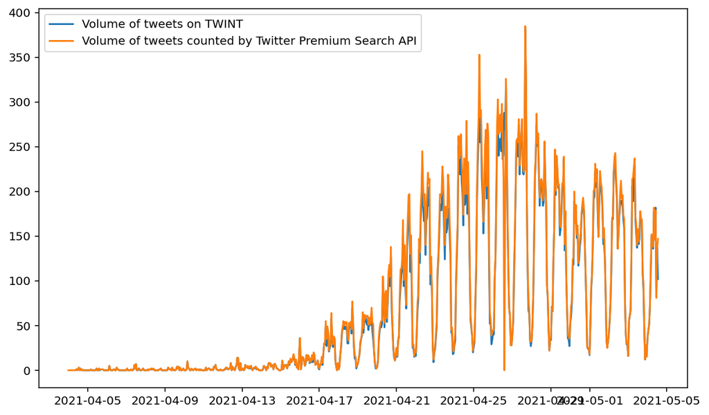

```python
plt.figure(figsize=(10,6))
plt.plot(twint_normal_grp['id'])
plt.plot(api_normal['timePeriod'], api_normal['count'])
plt.legend(['Volume of tweets on TWINT', 'Volume of tweets counted by Twitter Premium Search API'])
```

It appears that they match quite closely, with the Premium Search API counting slightly more tweets in certain circumstances. This is expected from the official Twitter documentation.

# Notebook state saving/restoration

```python
# save session
import dill
dill.dump_session('india-twitter-analysis.pkl')
```

```python
# restore session
import dill
dill.load_session('india-twitter-analysis.pkl')
```